# COS60008 Introduction to Data Science

## Assignment 3, 2024, Semester 1

## Student Details:

- Name: Harrison Stefanidis
- Student ID: 105260443
- Email: 105260443@student.swin.edu.au
- Submission Date: 05/06/2024
- TuteLab Class: Monday 12:30pm

## Task 1 - Problem Formulation, Data Acquisition and Preparation, Exploration and Modelling

### Sub-Task 1.1 - Problem Formulation, Data Acquisition and Preparation

```python
import pandas as pd

# Import Red Wine Quality Dataset (redwine_raw.csv) into df1
df1 = pd.read_csv('redwine_raw.csv', sep=';')

# Observe head of data
df1.head()
```

|  | fixed acidity | volatile acidity | citric acid | residual sugar | chlorides | free sulfur dioxide | total sulfur dioxide | density | pH | sulphates | alcohol | quality |
| --- | --- | --- | --- | --- | --- | --- | --- | --- | --- | --- | --- | --- |
| 0 | 7.4 | 0.70 | 0.00 | 1.9 | 0.076 | 11.0 | 34.0 | 0.9978 | 3.51 | 0.56 | 9.4 | 5 |
| 1 | 7.8 | 0.88 | 0.00 | 2.6 | 0.098 | 25.0 | 67.0 | 0.9968 | 3.20 | 0.68 | 9.8 | 5 |
| 2 | 7.8 | 0.76 | 0.04 | 2.3 | 0.092 | 15.0 | 54.0 | 0.9970 | 3.26 | 0.65 | 9.8 | 5 |
| 3 | 11.2 | 0.28 | 0.56 | 1.9 | 0.075 | 17.0 | 60.0 | 0.9980 | 3.16 | 0.58 | 9.8 | 6 |
| 4 | 7.4 | 0.70 | 0.00 | 1.9 | 0.076 | 11.0 | 34.0 | 0.9978 | 3.51 | 0.56 | 9.4 | 5 |

```python
# Observe relevant information on dataset
df1.info()
```

```
<class 'pandas.core.frame.DataFrame'>
RangeIndex: 1599 entries, 0 to 1598
Data columns (total 12 columns):
 #   Column                Non-Null Count  Dtype
---  ------                --------------  -----
 0   fixed acidity         1599 non-null   float64
 1   volatile acidity      1599 non-null   float64
 2   citric acid           1599 non-null   float64
 3   residual sugar        1599 non-null   float64
 4   chlorides             1599 non-null   float64
 5   free sulfur dioxide   1599 non-null   float64
 6   total sulfur dioxide  1599 non-null   float64
 7   density               1599 non-null   float64
 8   pH                    1599 non-null   float64
 9   sulphates             1599 non-null   float64
 10  alcohol               1599 non-null   float64
 11  quality               1599 non-null   int64
dtypes: float64(11), int64(1)
memory usage: 150.0 KB
```

```python
# Check for number of columns and number of data entries
df1.shape
```

```
(1599, 12)
```

```python
# Manually adjust the column titles for ease of accessibility
column_titles = ['Fixed_Acidity', 'Volatile_Acidity', 'Citric_Acid', 'Residual_Sugar', 'Chlorides',
                 'Free_Sulfur_Dioxide', 'Total_Sulfur_Dioxide', 'Density',
                 'pH', 'Sulphates', 'Alcohol', 'Quality']

# Rename the columns
df1.columns = column_titles

# Display the DataFrame again
df1.head()
```

|  | Fixed_Acidity | Volatile_Acidity | Citric_Acid | Residual_Sugar | Chlorides | Free_Sulfur_Dioxide | Total_Sulfur_Dioxide | Density | pH | Sulphates | Alcohol | Quality |
| --- | --- | --- | --- | --- | --- | --- | --- | --- | --- | --- | --- | --- |
| 0 | 7.4 | 0.70 | 0.00 | 1.9 | 0.076 | 11.0 | 34.0 | 0.9978 | 3.51 | 0.56 | 9.4 | 5 |
| 1 | 7.8 | 0.88 | 0.00 | 2.6 | 0.098 | 25.0 | 67.0 | 0.9968 | 3.20 | 0.68 | 9.8 | 5 |
| 2 | 7.8 | 0.76 | 0.04 | 2.3 | 0.092 | 15.0 | 54.0 | 0.9970 | 3.26 | 0.65 | 9.8 | 5 |
| 3 | 11.2 | 0.28 | 0.56 | 1.9 | 0.075 | 17.0 | 60.0 | 0.9980 | 3.16 | 0.58 | 9.8 | 6 |
| 4 | 7.4 | 0.70 | 0.00 | 1.9 | 0.076 | 11.0 | 34.0 | 0.9978 | 3.51 | 0.56 | 9.4 | 5 |

```python
# Check for missing values
missing_values = df1.isnull().sum()
print("Missing values per column:")
print(missing_values)

# Check for duplicate rows
duplicate_rows = df1.duplicated().sum()
print("Number of duplicate rows:", duplicate_rows)

# Check for unique values
unique_values = df1.apply(lambda column: list(column.unique()))
print(unique_values)

# Remove duplicates and reset index
df1 = df1.drop_duplicates()
df1 = df1.reset_index(drop=True)

# Finalise and save dataset
df1.to_csv('redwine_clean.csv', index=False)
```

```
Missing values per column:
Fixed_Acidity           0
Volatile_Acidity        0
Citric_Acid             0
Residual_Sugar          0
Chlorides               0
Free_Sulfur_Dioxide     0
Total_Sulfur_Dioxide    0
Density                 0
pH                      0
Sulphates               0
Alcohol                 0
Quality                 0
dtype: int64
Number of duplicate rows: 240
Fixed_Acidity           [7.4, 7.8, 11.2, 7.9, 7.3, 7.5, 6.7, 5.6, 8.9,...
Volatile_Acidity        [0.7, 0.88, 0.76, 0.28, 0.66, 0.6, 0.65, 0.58,...
Citric_Acid             [0.0, 0.04, 0.56, 0.06, 0.02, 0.36, 0.08, 0.29...
Residual_Sugar          [1.9, 2.6, 2.3, 1.8, 1.6, 1.2, 2.0, 6.1, 3.8, ...
Chlorides               [0.076, 0.098, 0.092, 0.075, 0.069, 0.065, 0.0...
Free_Sulfur_Dioxide     [11.0, 25.0, 15.0, 17.0, 13.0, 9.0, 16.0, 52.0...
Total_Sulfur_Dioxide    [34.0, 67.0, 54.0, 60.0, 40.0, 59.0, 21.0, 18....
Density                 [0.9978, 0.9968, 0.997, 0.998, 0.9964, 0.9946,...
pH                      [3.51, 3.2, 3.26, 3.16, 3.3, 3.39, 3.36, 3.35,...
Sulphates               [0.56, 0.68, 0.65, 0.58, 0.46, 0.47, 0.57, 0.8...
Alcohol                 [9.4, 9.8, 10.0, 9.5, 10.5, 9.2, 9.9, 9.1, 9.3...
Quality                                                [5, 6, 7, 4, 8, 3]
dtype: object
```

```python
# Import Cleaned Red Wine Quality Dataset (redwine_clean.csv) into df2
df2 = pd.read_csv('redwine_clean.csv')

# Double check for missing values
missing_values = df2.isnull().sum()
print("Missing values per column:")
print(missing_values)

# Double check for duplicate rows
duplicate_rows = df2.duplicated().sum()
print("Number of duplicate rows:", duplicate_rows)

# Double check for unique values
unique_values = df2.apply(lambda column: list(column.unique()))
print(unique_values)
```

```
Missing values per column:
Fixed_Acidity           0
Volatile_Acidity        0
Citric_Acid             0
Residual_Sugar          0
Chlorides               0
Free_Sulfur_Dioxide     0
Total_Sulfur_Dioxide    0
Density                 0
pH                      0
Sulphates               0
Alcohol                 0
Quality                 0
dtype: int64
Number of duplicate rows: 0
Fixed_Acidity           [7.4, 7.8, 11.2, 7.9, 7.3, 7.5, 6.7, 5.6, 8.9,...
Volatile_Acidity        [0.7, 0.88, 0.76, 0.28, 0.66, 0.6, 0.65, 0.58,...
Citric_Acid             [0.0, 0.04, 0.56, 0.06, 0.02, 0.36, 0.08, 0.29...
Residual_Sugar          [1.9, 2.6, 2.3, 1.8, 1.6, 1.2, 2.0, 6.1, 3.8, ...
Chlorides               [0.076, 0.098, 0.092, 0.075, 0.069, 0.065, 0.0...
Free_Sulfur_Dioxide     [11.0, 25.0, 15.0, 17.0, 13.0, 9.0, 16.0, 52.0...
Total_Sulfur_Dioxide    [34.0, 67.0, 54.0, 60.0, 40.0, 59.0, 21.0, 18....
Density                 [0.9978, 0.9968, 0.997, 0.998, 0.9964, 0.9946,...
pH                      [3.51, 3.2, 3.26, 3.16, 3.3, 3.39, 3.36, 3.35,...
Sulphates               [0.56, 0.68, 0.65, 0.58, 0.46, 0.47, 0.57, 0.8...
Alcohol                 [9.4, 9.8, 10.0, 9.5, 10.5, 9.2, 9.9, 9.1, 9.3...
Quality                                                [5, 6, 7, 4, 8, 3]
dtype: object
```

### Sub-Task 1.2 - Exploration

#### *How Does Free/Total Sulfur Dioxide Affect Final Wine Quality?*

```python
df2.describe()
```

|  | Fixed_Acidity | Volatile_Acidity | Citric_Acid | Residual_Sugar | Chlorides | Free_Sulfur_Dioxide | Total_Sulfur_Dioxide | Density | pH | Sulphates | Alcohol | Quality |
| --- | --- | --- | --- | --- | --- | --- | --- | --- | --- | --- | --- | --- |
| count | 1359.000000 | 1359.000000 | 1359.000000 | 1359.000000 | 1359.000000 | 1359.000000 | 1359.000000 | 1359.000000 | 1359.000000 | 1359.000000 | 1359.000000 | 1359.000000 |
| mean | 8.310596 | 0.529478 | 0.272333 | 2.523400 | 0.088124 | 15.893304 | 46.825975 | 0.996709 | 3.309787 | 0.658705 | 10.432315 | 5.623252 |
| std | 1.736990 | 0.183031 | 0.195537 | 1.352314 | 0.049377 | 10.447270 | 33.408946 | 0.001869 | 0.155036 | 0.170667 | 1.082065 | 0.823578 |
| min | 4.600000 | 0.120000 | 0.000000 | 0.900000 | 0.012000 | 1.000000 | 6.000000 | 0.990070 | 2.740000 | 0.330000 | 8.400000 | 3.000000 |
| 25% | 7.100000 | 0.390000 | 0.090000 | 1.900000 | 0.070000 | 7.000000 | 22.000000 | 0.995600 | 3.210000 | 0.550000 | 9.500000 | 5.000000 |
| 50% | 7.900000 | 0.520000 | 0.260000 | 2.200000 | 0.079000 | 14.000000 | 38.000000 | 0.996700 | 3.310000 | 0.620000 | 10.200000 | 6.000000 |
| 75% | 9.200000 | 0.640000 | 0.430000 | 2.600000 | 0.091000 | 21.000000 | 63.000000 | 0.997820 | 3.400000 | 0.730000 | 11.100000 | 6.000000 |
| max | 15.900000 | 1.580000 | 1.000000 | 15.500000 | 0.611000 | 72.000000 | 289.000000 | 1.003690 | 4.010000 | 2.000000 | 14.900000 | 8.000000 |

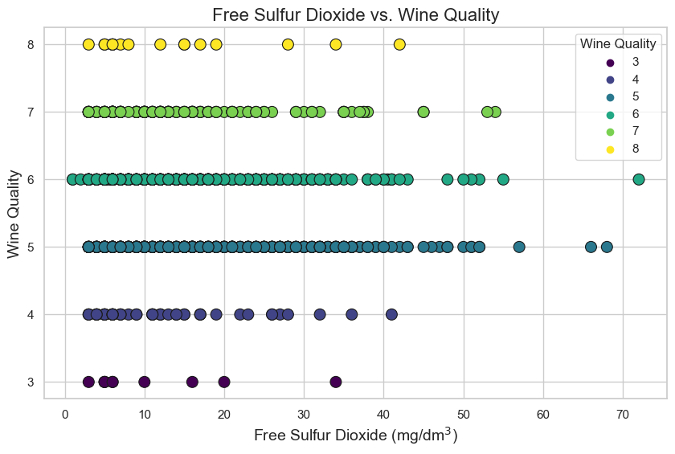

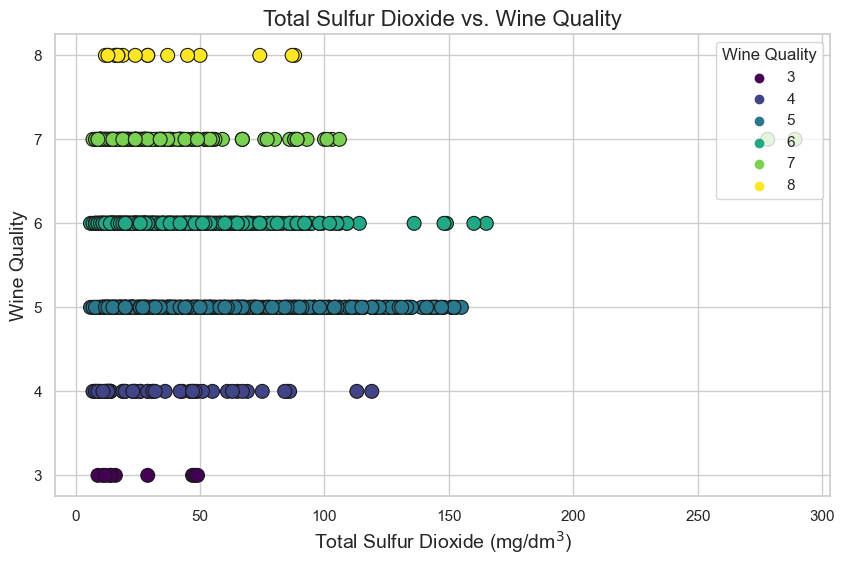

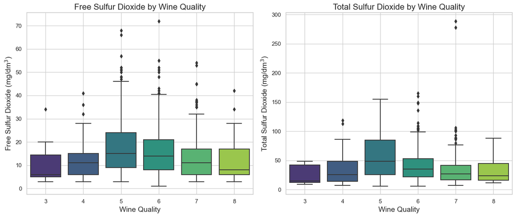

```python
import matplotlib.pyplot as plt
import seaborn as sns

# Set style
sns.set(style="whitegrid", palette="muted")

# Scatter plot of free sulfur dioxide vs. wine quality
plt.figure(figsize=(10, 6))
sns.scatterplot(data=df2, x='Free_Sulfur_Dioxide', y='Quality', hue='Quality', palette='viridis', s=100, edgecolor='k')
plt.title('Free Sulfur Dioxide vs. Wine Quality', fontsize=16)
plt.xlabel('Free Sulfur Dioxide (mg/dm$^3$)', fontsize=14)
plt.ylabel('Wine Quality', fontsize=14)
plt.legend(title='Wine Quality', loc='upper right')
plt.grid(True)
plt.show()

# Scatter plot of total sulfur dioxide vs. wine quality
plt.figure(figsize=(10, 6))
sns.scatterplot(data=df2, x='Total_Sulfur_Dioxide', y='Quality', hue='Quality', palette='viridis', s=100, edgecolor='k')
plt.title('Total Sulfur Dioxide vs. Wine Quality', fontsize=16)
plt.xlabel('Total Sulfur Dioxide (mg/dm$^3$)', fontsize=14)
plt.ylabel('Wine Quality', fontsize=14)
plt.legend(title='Wine Quality', loc='upper right')
plt.grid(True)
plt.show()

# Box plots of free and total sulfur dioxide grouped by wine quality
plt.figure(figsize=(14, 6))

# Box plot for free sulfur dioxide
plt.subplot(1, 2, 1)
sns.boxplot(data=df2, x='Quality', y='Free_Sulfur_Dioxide', palette='viridis')
plt.title('Free Sulfur Dioxide by Wine Quality', fontsize=16)
plt.xlabel('Wine Quality', fontsize=14)
plt.ylabel('Free Sulfur Dioxide (mg/dm$^3$)', fontsize=14)
plt.grid(True)

# Box plot for total sulfur dioxide
plt.subplot(1, 2, 2)
sns.boxplot(data=df2, x='Quality', y='Total_Sulfur_Dioxide', palette='viridis')
plt.title('Total Sulfur Dioxide by Wine Quality', fontsize=16)
plt.xlabel('Wine Quality', fontsize=14)
plt.ylabel('Total Sulfur Dioxide (mg/dm$^3$)', fontsize=14)
plt.grid(True)

plt.tight_layout()
plt.show()
```

An initial descriptive statistics insight was undertaken to analyse the general information presented by the Red Wine Cleaned Dataset, especially in subsequent questions. Although quality measurements ranged from 0 (being worst) to 10 (being best), the red wine dataset displayed ratings between 3-8. As total sulfur dioxide is the sum of free and bound sulfur dioxide to the red wine. The more free sulfur dioxide is in the red wine, the more protected the alcohol is from spoilage and oxidation.

Two initial scatterplots were formed to identify trends between free sulfur dioxide against wine quality, as well as total sulfur dioxide against wine quality. Subsequently, a comparison between the two was also created in two side-by-side box plots to further delve into a more accurate insight into the main data comparing the more observable points as opposed to the outliers which were presented in the scatterplots.

The total amount of sulfur dioxide that should be expected in red wine shouldn't exceed 200ppm. As such, general sulfur dioxide being present in red wine fermentation doesn't necessarily affect taste quality, but instead its shelf life. It is seen that sweeter wines typically have a higher amount of sulfur dioxide due to sugars being more readily available to combine with high proportions of sulfur dioxide. Overall, the majority of red wines fermented should be expected to have free sulfur dioxide of less than 20ppm and a total less than 50ppm to remain in the range of being capable of fermenting into a high quality alcohol.

#### *Can Fixed/Volatile Acidity Alter Red Wine Quality?*

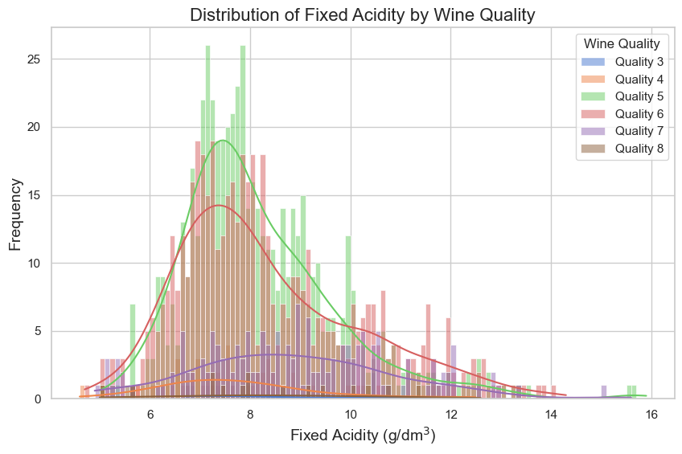

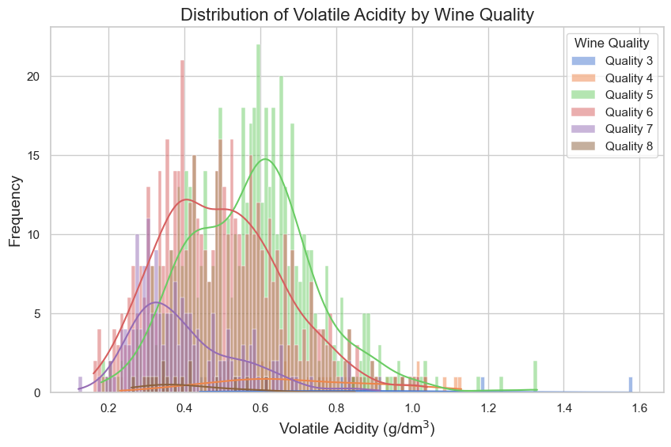

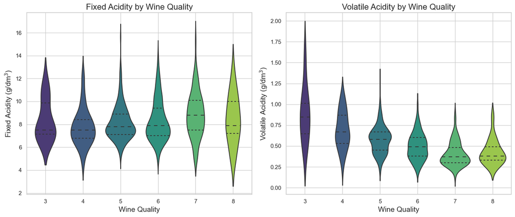

```python
# Histogram of fixed acidity grouped by wine quality
plt.figure(figsize=(10, 6))
for quality in sorted(df2['Quality'].unique()):
    subset = df2[df2['Quality'] == quality]
    sns.histplot(subset['Fixed_Acidity'], kde=True, binwidth=0.1, label=f'Quality {quality}')

plt.title('Distribution of Fixed Acidity by Wine Quality', fontsize=16)
plt.xlabel('Fixed Acidity (g/dm$^3$)', fontsize=14)
plt.ylabel('Frequency', fontsize=14)
plt.legend(title='Wine Quality', loc='upper right')
plt.grid(True)
plt.show()

# Histogram of volatile acidity grouped by wine quality
plt.figure(figsize=(10, 6))
for quality in sorted(df2['Quality'].unique()):
    subset = df2[df2['Quality'] == quality]
    sns.histplot(subset['Volatile_Acidity'], kde=True, binwidth=0.01, label=f'Quality {quality}')

plt.title('Distribution of Volatile Acidity by Wine Quality', fontsize=16)
plt.xlabel('Volatile Acidity (g/dm$^3$)', fontsize=14)
plt.ylabel('Frequency', fontsize=14)
plt.legend(title='Wine Quality', loc='upper right')
plt.grid(True)
plt.show()

# Violin plots of fixed and volatile acidity grouped by wine quality
plt.figure(figsize=(14, 6))

# Violin plot for fixed acidity
plt.subplot(1, 2, 1)
sns.violinplot(data=df2, x='Quality', y='Fixed_Acidity', palette='viridis', inner='quartile')
plt.title('Fixed Acidity by Wine Quality', fontsize=16)
plt.xlabel('Wine Quality', fontsize=14)
plt.ylabel('Fixed Acidity (g/dm$^3$)', fontsize=14)
plt.grid(True)

# Violin plot for volatile acidity
plt.subplot(1, 2, 2)
sns.violinplot(data=df2, x='Quality', y='Volatile_Acidity', palette='viridis', inner='quartile')
plt.title('Volatile Acidity by Wine Quality', fontsize=16)
plt.xlabel('Wine Quality', fontsize=14)
plt.ylabel('Volatile Acidity (g/dm$^3$)', fontsize=14)
plt.grid(True)

plt.tight_layout()
plt.show()
```

Both fixed and volatile acidity in wine production are essential for the ultimate quality that is produced when fermenting this alcohol. Due to this, anything above 0.72 g/L for volatile acidity will ensure that quality decreases significantly, causing a deterioration in wine aroma and flavour. Fixed acidity further highlights the outcome of fermentation quality as it works to maintain and preserve red wine's natural qualities and colour.

To determine how each types of acidity affect wine quality, two separate histograms were created to comprehend how each factor affected the taste rating of wine. A legend was used to easily identify which wine was of which quality rating, alongside the frequency of them based on both volatile and fixed acidity. To observe the majority of datapoints, a violin plot comparison was made with the same variables for further insight.

The histograms presenting both volatile and fixed acidity against wine quality illustrate a general bell curve of the frequency of each quality type of wine. It is generally seen that fixed acidity doesn't necessarily impact overall wine quality to too much of an extent as all qualities of wine are observed at around a fixed acidity of approximately 8 g/dm$^{3}$. However, volatile acidity plays a key role in ultimate quality of red wine as a lower amount of it, specifically anything less than 0.50 g/dm$^{3}$ has a significant impact on increasing wine quality. This is further shown by the violin plot comparison, where there is an obvious trend of increasing wine quality as volatile acidity decreases.

#### *Are pH and Sulphates the Most Influential Factors in Determining Wine Quality?*

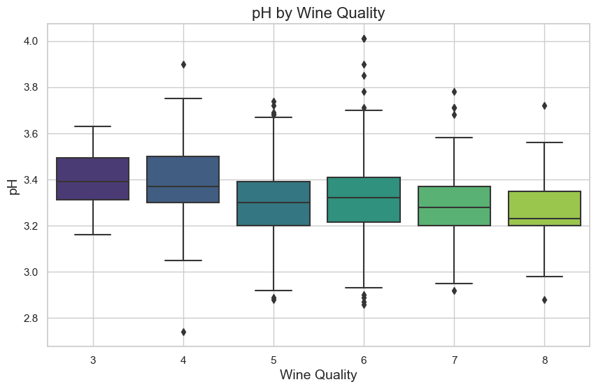

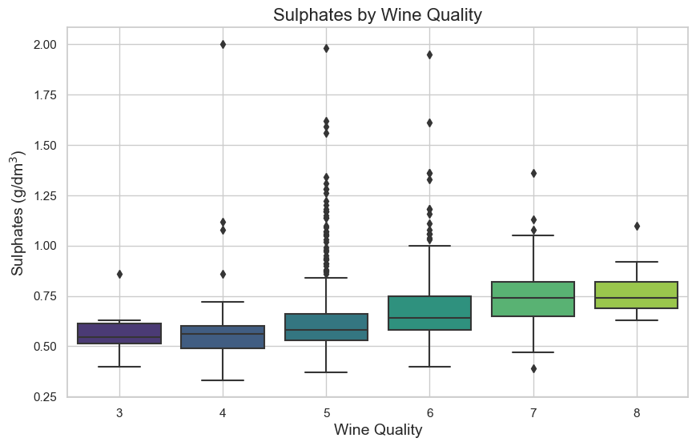

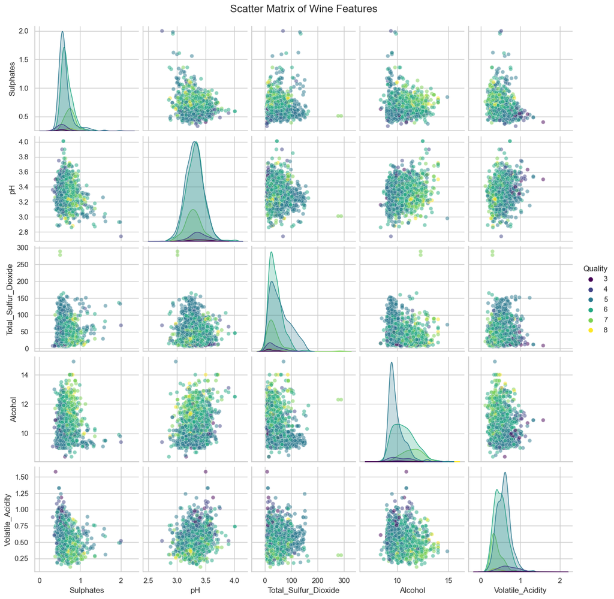

```python
# Box plot for pH vs wine quality
plt.figure(figsize=(10, 6))
sns.boxplot(data=df2, x='Quality', y='pH', palette='viridis')
plt.title('pH by Wine Quality', fontsize=16)
plt.xlabel('Wine Quality', fontsize=14)
plt.ylabel('pH', fontsize=14)
plt.grid(True)
plt.show()

# Box plot for sulphates vs wine quality
plt.figure(figsize=(10, 6))
sns.boxplot(data=df2, x='Quality', y='Sulphates', palette='viridis')
plt.title('Sulphates by Wine Quality', fontsize=16)
plt.xlabel('Wine Quality', fontsize=14)
plt.ylabel('Sulphates (g/dm$^3$)', fontsize=14)
plt.grid(True)
plt.show()

# Select relevant columns for the scatter matrix
df_subset = df2[['Sulphates', 'pH', 'Total_Sulfur_Dioxide', 'Alcohol', 'Volatile_Acidity', 'Quality']]

# Create the scatter matrix (pair plot)
pairplot = sns.pairplot(df_subset, hue='Quality', palette='viridis', diag_kind='kde', markers='o', plot_kws={'alpha':0.5})
pairplot.fig.suptitle('Scatter Matrix of Wine Features', y=1.02, fontsize=16)

# Show the plot
plt.show()
```

The fermentation process to create wine is dependant on microbiological stability, and thus if the pH range exceeds anywhere between 2.9-3.8 (ideal brewing range), the solubility of nutrients required to create red wine will be significantly affected as well as causing denaturation of proteins that are essential for fermentation reactions. In addition, sulphates are an imperative substance which allows this alcohol to become further enhanced on top of it being an antimicrobial agent to prevent bacterial growth in wine.

In order to explore which pH and the optimal amount of sulphates is ideal for higher quality wines, two box plots were created displaying differing pH/sulphate values against the overall quality of the wine samples. Again, a trend was shown where decreasing pH levels indicated higher quality wine production. A value of slightly above 3.2 pH strongly correlates to wine quality of rating 8. A similar observation was seen with sulphates vs. wine quality. To an extent, due to an increase in sulphate amounts, quality of red wine increased. At a value of 0.75 g/dm$^3$, extremely high ratings of 7 and 8 were observed for these wine samples.

Finally, a scatter matrix utilising a select 5 features against wine quality were used. These variables were 'sulphates', 'pH', 'total sulfur dioxide', 'alcohol', and 'volatile acidity'. Unfortunately, no obvious trends were observed when comparing these features against each other, meaning that each individual variable affects wine quality separately.

### Sub-Task 1.3 - Modelling Using Neural Network and Logistic Regression Models

```python
from sklearn.model_selection import train_test_split

# Convert wine quality to binary categories: 1 (Good) if quality >= 6, else 0 (Bad)
df2['Quality'] = df2['Quality'].apply(lambda x: 1 if x >= 6 else 0)

# Define features and target variables
X = df2.drop(columns=['Quality'])  # General features excluding target variable
y = df2['Quality']  # Target variable

# Split data into training and testing sets (80% training, 20% testing)
X_train, X_test, y_train, y_test = train_test_split(X, y, test_size=0.2, random_state=42)

# Print the shapes of the training and testing sets
print("Training set shape:", X_train.shape,
      "Testing set shape:", X_test.shape)
```

```
Training set shape: (1087, 11) Testing set shape: (272, 11)
```

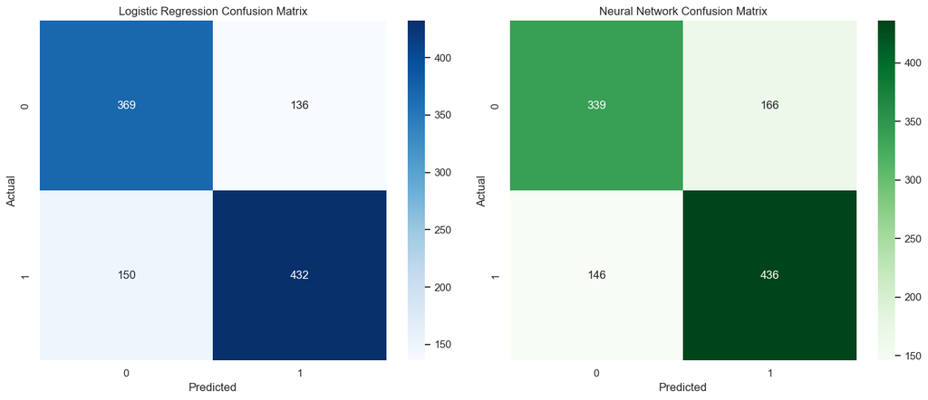

```
Logistic Regression Metrics:
Accuracy: 0.7368905243790248
Precision: 0.7375290985266884
Recall: 0.7368905243790248
F1 Score: 0.7370875883714653

Neural Network Metrics:
Accuracy: 0.7129714811407544
Precision: 0.7125062848292658
Recall: 0.7129714811407544
F1 Score: 0.7124964305277093
```

```python
from sklearn.model_selection import cross_val_predict, cross_val_score
from sklearn.linear_model import LogisticRegression
from sklearn.neural_network import MLPClassifier
from sklearn.preprocessing import StandardScaler
from sklearn.metrics import accuracy_score, confusion_matrix, precision_score, recall_score, f1_score
import numpy as np

# Scale the features
scaler = StandardScaler()
X_train_scaled = scaler.fit_transform(X_train)
X_test_scaled = scaler.transform(X_test)

# Define models and manually set hyperparameters
logistic_regression = LogisticRegression(penalty='l2', C=1.0, solver='lbfgs', max_iter=1000, random_state=42)
neural_network = MLPClassifier(hidden_layer_sizes=(50,), activation='relu', solver='adam', alpha=0.0001,
                               learning_rate='adaptive', max_iter=3000, random_state=42)

# Perform cross-validation and get predictions
y_pred_lr = cross_val_predict(logistic_regression, X_train_scaled, y_train, cv=5)
y_pred_nn = cross_val_predict(neural_network, X_train_scaled, y_train, cv=5)

# Calculate confusion matrix for logistic regression
conf_matrix_lr = confusion_matrix(y_train, y_pred_lr)

# Calculate confusion matrix for neural network
conf_matrix_nn = confusion_matrix(y_train, y_pred_nn)

# Plot confusion matrices
fig, axes = plt.subplots(1, 2, figsize=(14, 6))

# Heatmap for logistic regression
sns.heatmap(conf_matrix_lr, annot=True, fmt='d', cmap='Blues', ax=axes[0])
axes[0].set_title('Logistic Regression Confusion Matrix')
axes[0].set_xlabel('Predicted')
axes[0].set_ylabel('Actual')

# Heatmap for neural network
sns.heatmap(conf_matrix_nn, annot=True, fmt='d', cmap='Greens', ax=axes[1])
axes[1].set_title('Neural Network Confusion Matrix')
axes[1].set_xlabel('Predicted')
axes[1].set_ylabel('Actual')

plt.tight_layout()
plt.show()

# Calculate performance metrics for logistic regression
accuracy_lr = accuracy_score(y_train, y_pred_lr)
precision_lr = precision_score(y_train, y_pred_lr, average='weighted')
recall_lr = recall_score(y_train, y_pred_lr, average='weighted')
f1_lr = f1_score(y_train, y_pred_lr, average='weighted')

# Calculate performance metrics for neural network
accuracy_nn = accuracy_score(y_train, y_pred_nn)
precision_nn = precision_score(y_train, y_pred_nn, average='weighted')
recall_nn = recall_score(y_train, y_pred_nn, average='weighted')
f1_nn = f1_score(y_train, y_pred_nn, average='weighted')

print("\nLogistic Regression Metrics:")
print(f"Accuracy: {accuracy_lr}")
print(f"Precision: {precision_lr}")
print(f"Recall: {recall_lr}")
print(f"F1 Score: {f1_lr}")

print("\nNeural Network Metrics:")
print(f"Accuracy: {accuracy_nn}")
print(f"Precision: {precision_nn}")
print(f"Recall: {recall_nn}")
print(f"F1 Score: {f1_nn}")
```

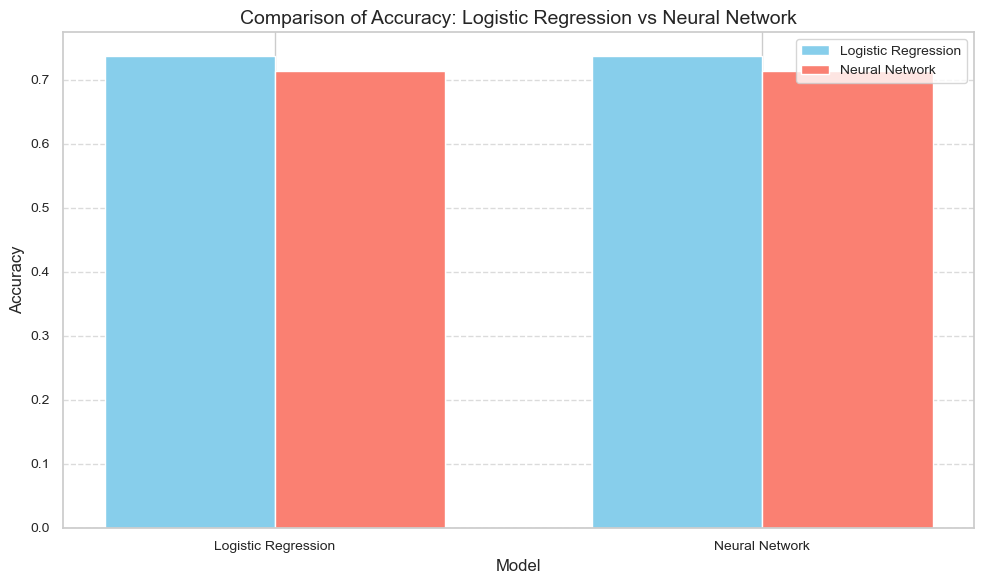

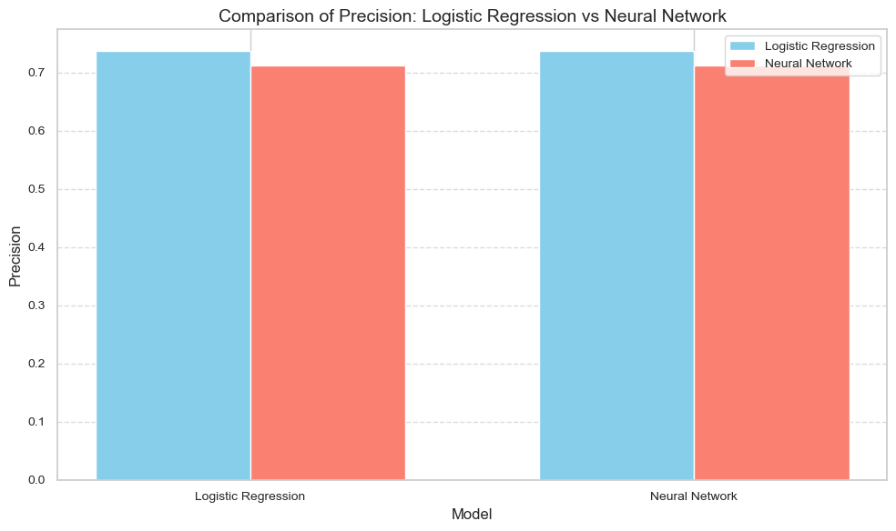

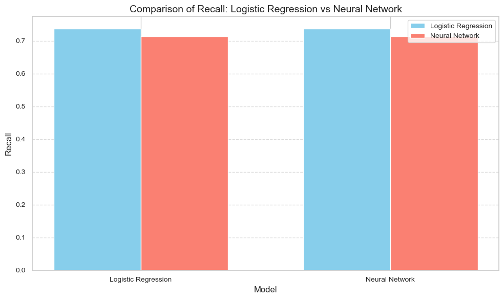

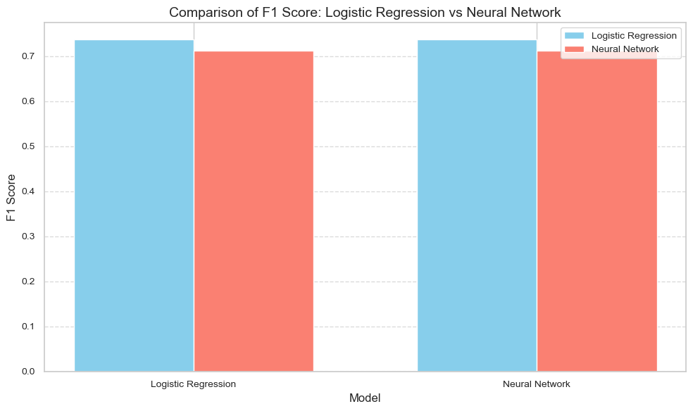

```python
# Define a function to plot the other scores for both logistic regression and neural network
def plot_evaluation_metrics(metric_values_lr, metric_values_nn, metric_name):
    models = ['Logistic Regression', 'Neural Network']

    plt.figure(figsize=(10, 6))

    bar_width = 0.35
    index = np.arange(len(models))

    plt.bar(index, metric_values_lr, color='skyblue', width=bar_width, label='Logistic Regression')
    plt.bar(index + bar_width, metric_values_nn, color='salmon', width=bar_width, label='Neural Network')

    plt.xlabel('Model', fontsize=12)
    plt.ylabel(metric_name, fontsize=12)
    plt.title(f'Comparison of {metric_name}: Logistic Regression vs Neural Network', fontsize=14)

    plt.xticks(index + bar_width / 2, models, fontsize=10)
    plt.yticks(fontsize=10)

    plt.legend(fontsize=10)
    plt.grid(axis='y', linestyle='--', alpha=0.7)

    plt.tight_layout()
    plt.show()

# Plot each metric separately
plot_evaluation_metrics([accuracy_lr], [accuracy_nn], metric_name='Accuracy')
plot_evaluation_metrics([precision_lr], [precision_nn], metric_name='Precision')
plot_evaluation_metrics([recall_lr], [recall_nn], metric_name='Recall')
plot_evaluation_metrics([f1_lr], [f1_nn], metric_name='F1 Score')
```

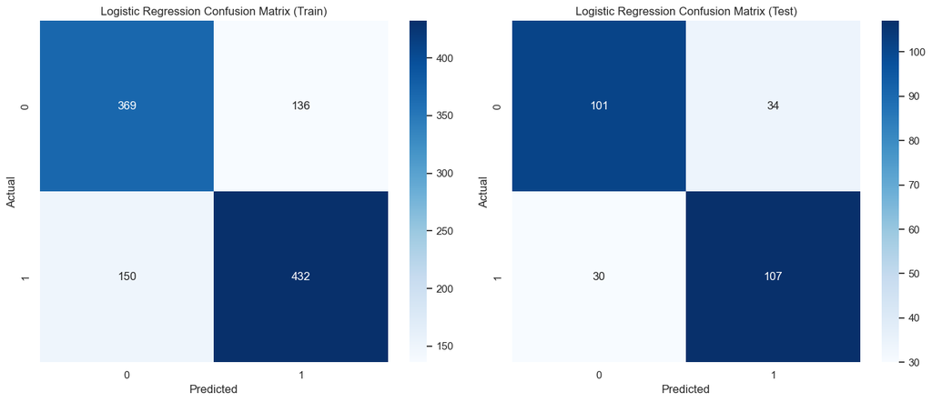

```
Logistic Regression Metrics (Train):
Accuracy: 0.7368905243790248
Precision: 0.7375290985266884
Recall: 0.7368905243790248
F1 Score: 0.7370875883714653

Logistic Regression Metrics (Test):
Accuracy: 0.7647058823529411
Precision: 0.7648842223262539
Recall: 0.7647058823529411
F1 Score: 0.7646295170851377
```

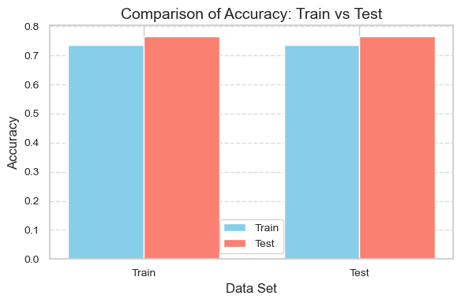

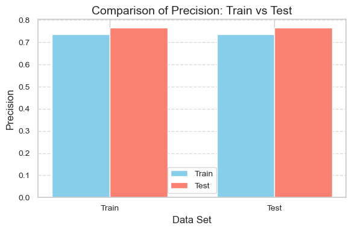

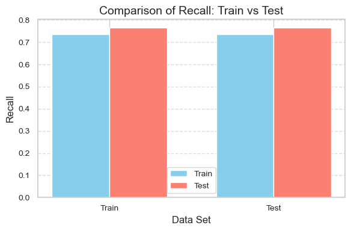

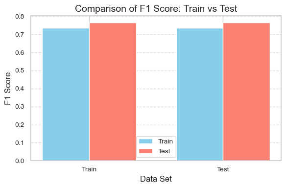

```python
# Logistic regression identified as optimal model, process repeated with novel test/train data
X = df2.drop(columns=['Quality'])  # General features excluding target variable
y = df2['Quality']  # Target variable

# Split data into training and testing sets (80% training, 20% testing)
X_train, X_test, y_train, y_test = train_test_split(X, y, test_size=0.2, random_state=42)

# Scale the features
scaler = StandardScaler()
X_train_scaled = scaler.fit_transform(X_train)
X_test_scaled = scaler.transform(X_test)

# Define the logistic regression model with manually set hyperparameters
logistic_regression = LogisticRegression(penalty='l2', C=1.0, solver='lbfgs', max_iter=1000, random_state=42)

# Perform cross-validation and get predictions on training data
y_pred_lr_train = cross_val_predict(logistic_regression, X_train_scaled, y_train, cv=5)

# Calculate confusion matrix for the training predictions
conf_matrix_lr_train = confusion_matrix(y_train, y_pred_lr_train)

# Train the model on the full training data
logistic_regression.fit(X_train_scaled, y_train)

# Predict on the test data
y_pred_lr_test = logistic_regression.predict(X_test_scaled)

# Calculate confusion matrix for the test predictions
conf_matrix_lr_test = confusion_matrix(y_test, y_pred_lr_test)

# Plot confusion matrices for training and test data
fig, axes = plt.subplots(1, 2, figsize=(14, 6))

# Heatmap for training data
sns.heatmap(conf_matrix_lr_train, annot=True, fmt='d', cmap='Blues', ax=axes[0])
axes[0].set_title('Logistic Regression Confusion Matrix (Train)')
axes[0].set_xlabel('Predicted')
axes[0].set_ylabel('Actual')

# Heatmap for test data
sns.heatmap(conf_matrix_lr_test, annot=True, fmt='d', cmap='Blues', ax=axes[1])
axes[1].set_title('Logistic Regression Confusion Matrix (Test)')
axes[1].set_xlabel('Predicted')
axes[1].set_ylabel('Actual')

plt.tight_layout()
plt.show()

# Calculate performance metrics for training data (logistic regression)
accuracy_lr_train = accuracy_score(y_train, y_pred_lr_train)
precision_lr_train = precision_score(y_train, y_pred_lr_train, average='weighted')
recall_lr_train = recall_score(y_train, y_pred_lr_train, average='weighted')
f1_lr_train = f1_score(y_train, y_pred_lr_train, average='weighted')

print("\nLogistic Regression Metrics (Train):")
print(f"Accuracy: {accuracy_lr_train}")
print(f"Precision: {precision_lr_train}")
print(f"Recall: {recall_lr_train}")
print(f"F1 Score: {f1_lr_train}")

# Calculate performance metrics for test data (logistic regression)
accuracy_lr_test = accuracy_score(y_test, y_pred_lr_test)
precision_lr_test = precision_score(y_test, y_pred_lr_test, average='weighted')
recall_lr_test = recall_score(y_test, y_pred_lr_test, average='weighted')
f1_lr_test = f1_score(y_test, y_pred_lr_test, average='weighted')

print("\nLogistic Regression Metrics (Test):")
print(f"Accuracy: {accuracy_lr_test}")
print(f"Precision: {precision_lr_test}")
print(f"Recall: {recall_lr_test}")
print(f"F1 Score: {f1_lr_test}")

# Define a function to plot the evaluation metrics
def plot_evaluation_metrics(metric_train, metric_test, metric_name):
    labels = ['Train', 'Test']

    plt.figure(figsize=(6, 4))

    bar_width = 0.35
    index = np.arange(len(labels))

    plt.bar(index, metric_train, color='skyblue', width=bar_width, label='Train')
    plt.bar(index + bar_width, metric_test, color='salmon', width=bar_width, label='Test')

    plt.xlabel('Data Set', fontsize=12)
    plt.ylabel(metric_name, fontsize=12)
    plt.title(f'Comparison of {metric_name}: Train vs Test', fontsize=14)

    plt.xticks(index + bar_width / 2, labels, fontsize=10)
    plt.yticks(fontsize=10)

    plt.legend(fontsize=10)
    plt.grid(axis='y', linestyle='--', alpha=0.7)

    plt.tight_layout()
    plt.show()

# Plot each metric separately for logistic regression
plot_evaluation_metrics([accuracy_lr_train], [accuracy_lr_test], metric_name='Accuracy')
plot_evaluation_metrics([precision_lr_train], [precision_lr_test], metric_name='Precision')
plot_evaluation_metrics([recall_lr_train], [recall_lr_test], metric_name='Recall')
plot_evaluation_metrics([f1_lr_train], [f1_lr_test], metric_name='F1 Score')
```